# py_autokeras_binaryclass_tabular_data_example

### January 7, 2022

Template Credit: Adapted from a template made available by Dr. Jason Brownlee of Machine Learning Mastery. [https://machinelearningmastery.com/]

INTRODUCTION: [Sample Paragraph - The data file patterns obtained by bouncing sonar signals off a metal cylinder or a rock at various angles and under various conditions. The transmitted sonar signal is a frequency-modulated chirp, rising in frequency. The data set contains signals obtained from a variety of different aspect angles, spanning 90 degrees for the cylinder and 180 degrees for the rock. Each pattern is a set of 60 numbers in the range 0.0 to 1.0. Each number represents the energy within a particular frequency band, integrated over a certain period of time.]

ANALYSIS: [Sample Paragraph - After a series of tuning trials, the best AutoKeras model processed the training dataset with a ROC/AUC score of 100%. When we processed the test dataset with the final model, the model achieved a ROC/AUC score of 90.37%.]

CONCLUSION: [Sample Paragraph - In this iteration, the AutoKeras model appeared to be a suitable algorithm for modeling this dataset.]

Dataset Reference: [https://archive.ics.uci.edu/ml/datasets/Connectionist+Bench+%28Sonar%2C+Mines+vs.+Rocks%29]

One potential source of performance benchmark: [https://archive.ics.uci.edu/ml/datasets/Connectionist+Bench+%28Sonar%2C+Mines+vs.+Rocks%29]

## Task 1 - Prepare Environment

```python
# # Install the necessary packages for Colab
# !pip install python-dotenv PyMySQL
```

```python
# # Retrieve the GPU information from Colab
# gpu_info = !nvidia-smi
# gpu_info = '\n'.join(gpu_info)
# if gpu_info.find('failed') >= 0:
#     print('Select the Runtime → "Change runtime type" menu to enable a GPU accelerator, ')
#     print('and then re-execute this cell.')
# else:
#     print(gpu_info)
```

```python
# # Retrieve the memory configuration from Colab
# from psutil import virtual_memory
# ram_gb = virtual_memory().total / 1e9
# print('Your runtime has {:.1f} gigabytes of available RAM\n'.format(ram_gb))

# if ram_gb < 20:
#     print('To enable a high-RAM runtime, select the Runtime → "Change runtime type"')
#     print('menu, and then select High-RAM in the Runtime shape dropdown. Then, ')
#     print('re-execute this cell.')
# else:
#     print('You are using a high-RAM runtime!')
```

```python
# # Mount Google Drive locally for loading the dotenv files
# from dotenv import load_dotenv
# from google.colab import drive
# drive.mount('/content/gdrive')
# gdrivePrefix = '/content/gdrive/My Drive/Colab_Downloads/'
# env_path = '/content/gdrive/My Drive/Colab Notebooks/'
# dotenv_path = env_path + "python_script.env"
# load_dotenv(dotenv_path=dotenv_path)
```

```python
# Retrieve the CPU information
ncpu = !nproc
print("The number of available CPUs is:", ncpu[0])
```

```
The number of available CPUs is: 8
```

### 1.a) Load libraries and modules

```python
# Set the random seed number for reproducible results
RNG_SEED = 888
```

```python
import random
random.seed(RNG_SEED)
import numpy as np
np.random.seed(RNG_SEED)
import pandas as pd
import seaborn as sns
import matplotlib.pyplot as plt
import os
import sys
import math
# import boto3
from datetime import datetime
from sklearn import preprocessing
from sklearn.model_selection import train_test_split
from sklearn.metrics import classification_report
from sklearn.metrics import confusion_matrix
from sklearn.metrics import accuracy_score
from sklearn.metrics import roc_auc_score
from sklearn.pipeline import Pipeline
from sklearn import compose
from sklearn import impute

# from sklearn.feature_selection import RFE
# from imblearn.pipeline import Pipeline
# from imblearn.over_sampling import SMOTE
# from imblearn.under_sampling import RandomUnderSampler

import tensorflow as tf
tf.random.set_seed(RNG_SEED)
import keras_tuner
import autokeras as ak
```

```
2022-01-05 18:12:28.027255: I tensorflow/stream_executor/platform/default/dso_loader.cc:53] Successfully opened dynamic library libcudart.so.11.0
```

### 1.b) Set up the controlling parameters and functions

```python
# Begin the timer for the script processing
START_TIME_SCRIPT = datetime.now()
```

```python
# Set up the number of CPU cores available for multi-thread processing
N_JOBS = 1

# Set up the flag to stop sending progress emails (setting to True will send status emails!)
NOTIFY_STATUS = False

# Set the percentage sizes for splitting the dataset
TEST_SET_RATIO = 0.2
VAL_SET_RATIO = 0.2

# Set the number of folds for cross validation
N_FOLDS = 5
N_ITERATIONS = 1

# Set various default modeling parameters
DEFAULT_LOSS = 'binary_crossentropy'
DEFAULT_METRICS = [tf.keras.metrics.AUC()]
MAX_EPOCHS = 20
BATCH_SIZE = 16
MAX_TRIALS = 100

# Check the number of GPUs accessible through TensorFlow
print('Num GPUs Available:', len(tf.config.list_physical_devices('GPU')))

# Print out the TensorFlow version for confirmation
print('TensorFlow version:', tf.__version__)
```

[output not shown]

```
Num GPUs Available: 1
TensorFlow version: 2.5.2
```

```python
# Set up the email notification function
def status_notify(msg_text):
    access_key = os.environ.get('SNS_ACCESS_KEY')
    secret_key = os.environ.get('SNS_SECRET_KEY')
    aws_region = os.environ.get('SNS_AWS_REGION')
    topic_arn = os.environ.get('SNS_TOPIC_ARN')
    if (access_key is None) or (secret_key is None) or (aws_region is None):
        sys.exit("Incomplete notification setup info. Script Processing Aborted!!!")
    sns = boto3.client('sns', aws_access_key_id=access_key, aws_secret_access_key=secret_key, region_name=aws_region)
    response = sns.publish(TopicArn=topic_arn, Message=msg_text)
    if response['ResponseMetadata']['HTTPStatusCode'] != 200 :
        print('Status notification not OK with HTTP status code:', response['ResponseMetadata']['HTTPStatusCode'])
```

```python
# Reset the random number generators
def reset_random(x=RNG_SEED):
    random.seed(x)
    np.random.seed(x)
    tf.random.set_seed(x)
```

```python
if NOTIFY_STATUS: status_notify("Task 1 - Prepare Environment has begun! " + datetime.now().strftime('%a %B %d, %Y %I:%M:%S %p'))
```

### 1.c) Load dataset

```python
dataset_path = 'https://dainesanalytics.com/datasets/example-dataset-for-template/sonar_data.txt'
attrNames = ['attr' + str(i).zfill(2) for i in range(1,61)]
colNames = attrNames + ['target']
df_dataset_import = pd.read_csv(dataset_path, names=colNames, sep=',', header=None, index_col=False)

# Take a peek at the dataframe after import
print(df_dataset_import.head(10))
```

```
   attr01  attr02  attr03  attr04  attr05  attr06  attr07  attr08  attr09  \
0  0.0200  0.0371  0.0428  0.0207  0.0954  0.0986  0.1539  0.1601  0.3109
1  0.0453  0.0523  0.0843  0.0689  0.1183  0.2583  0.2156  0.3481  0.3337
2  0.0262  0.0582  0.1099  0.1083  0.0974  0.2280  0.2431  0.3771  0.5598
3  0.0100  0.0171  0.0623  0.0205  0.0205  0.0368  0.1098  0.1276  0.0598
4  0.0762  0.0666  0.0481  0.0394  0.0590  0.0649  0.1209  0.2467  0.3564
5  0.0286  0.0453  0.0277  0.0174  0.0384  0.0990  0.1201  0.1833  0.2105
6  0.0317  0.0956  0.1321  0.1408  0.1674  0.1710  0.0731  0.1401  0.2083
7  0.0519  0.0548  0.0842  0.0319  0.1158  0.0922  0.1027  0.0613  0.1465
8  0.0223  0.0375  0.0484  0.0475  0.0647  0.0591  0.0753  0.0098  0.0684
9  0.0164  0.0173  0.0347  0.0070  0.0187  0.0671  0.1056  0.0697  0.0962

   attr10  ...  attr52  attr53  attr54  attr55  attr56  attr57  attr58  \
0  0.2111  ...  0.0027  0.0065  0.0159  0.0072  0.0167  0.0180  0.0084
1  0.2872  ...  0.0084  0.0089  0.0048  0.0094  0.0191  0.0140  0.0049
```

[output cut: 22 more lines]

```python
df_dataset_import.info(verbose=True)
```

```
<class 'pandas.core.frame.DataFrame'>
RangeIndex: 208 entries, 0 to 207
Data columns (total 61 columns):
 #   Column  Non-Null Count  Dtype
---  ------  --------------  -----
 0   attr01  208 non-null    float64
 1   attr02  208 non-null    float64
 2   attr03  208 non-null    float64
 3   attr04  208 non-null    float64
 4   attr05  208 non-null    float64
 5   attr06  208 non-null    float64
 6   attr07  208 non-null    float64
 7   attr08  208 non-null    float64
 8   attr09  208 non-null    float64
 9   attr10  208 non-null    float64
```

[output cut: 53 more lines]

```python
print(df_dataset_import.describe())
```

```
           attr01      attr02      attr03      attr04      attr05      attr06  \
count  208.000000  208.000000  208.000000  208.000000  208.000000  208.000000
mean     0.029164    0.038437    0.043832    0.053892    0.075202    0.104570
std      0.022991    0.032960    0.038428    0.046528    0.055552    0.059105
min      0.001500    0.000600    0.001500    0.005800    0.006700    0.010200
25%      0.013350    0.016450    0.018950    0.024375    0.038050    0.067025
50%      0.022800    0.030800    0.034300    0.044050    0.062500    0.092150
75%      0.035550    0.047950    0.057950    0.064500    0.100275    0.134125
max      0.137100    0.233900    0.305900    0.426400    0.401000    0.382300

           attr07      attr08      attr09      attr10  ...      attr51  \
count  208.000000  208.000000  208.000000  208.000000  ...  208.000000
mean     0.121747    0.134799    0.178003    0.208259  ...    0.016069
std      0.061788    0.085152    0.118387    0.134416  ...    0.012008
min      0.003300    0.005500    0.007500    0.011300  ...    0.000000
25%      0.080900    0.080425    0.097025    0.111275  ...    0.008425
50%      0.106950    0.112100    0.152250    0.182400  ...    0.013900
75%      0.154000    0.169600    0.233425    0.268700  ...    0.020825
max      0.372900    0.459000    0.682800    0.710600  ...    0.100400

           attr52      attr53      attr54      attr55      attr56      attr57  \
count  208.000000  208.000000  208.000000  208.000000  208.000000  208.000000
mean     0.013420    0.010709    0.010941    0.009290    0.008222    0.007820
std      0.009634    0.007060    0.007301    0.007088    0.005736    0.005785
min      0.000800    0.000500    0.001000    0.000600    0.000400    0.000300
25%      0.007275    0.005075    0.005375    0.004150    0.004400    0.003700
50%      0.011400    0.009550    0.009300    0.007500    0.006850    0.005950
75%      0.016725    0.014900    0.014500    0.012100    0.010575    0.010425
max      0.070900    0.039000    0.035200    0.044700    0.039400    0.035500

           attr58      attr59      attr60
count  208.000000  208.000000  208.000000
mean     0.007949    0.007941    0.006507
std      0.006470    0.006181    0.005031
min      0.000300    0.000100    0.000600
25%      0.003600    0.003675    0.003100
50%      0.005800    0.006400    0.005300
75%      0.010350    0.010325    0.008525
max      0.044000    0.036400    0.043900

[8 rows x 60 columns]
```

```python
print(df_dataset_import.isnull().sum())
print('Total number of NaN in the dataframe: ', df_dataset_import.isnull().sum().sum())
```

```
attr01    0
attr02    0
attr03    0
attr04    0
attr05    0
         ..
attr57    0
attr58    0
attr59    0
attr60    0
target    0
Length: 61, dtype: int64
Total number of NaN in the dataframe:  0
```

```python
# Get grouping size for the target variable
print(df_dataset_import.groupby('target').size())
```

```
target
M    111
R     97
dtype: int64
```

### 1.d) Data Cleaning

```python
# Standardize the class column to the name of targetVar if required
# df_dataset_import = df_dataset_import.rename(columns={'old_name': 'targetVar'})

# Dropping features
# df_dataset_import.drop(columns=['column1','column2','column3'], inplace=True)

# Impute missing values
# df_dataset_import['col_name'].fillna('someValue', inplace=True)
# df_dataset_import['col_name'].fillna(value=df_dataset_import['col_name'].median(), inplace=True)

# Convert columns from one data type to another
# df_dataset_import.column_name = df_dataset_import.column_name.astype('int')
# df_dataset_import.column_name = df_dataset_import.column_name.astype('category')

# Convert features with R/M levels into categorical feature of 0/1
def reclass_somecol(target):
    if target == 'M': return 1
    else: return 0
df_dataset_import['target'] = df_dataset_import['target'].apply(reclass_somecol)

# Take a peek at the dataframe after cleaning
print(df_dataset_import.head(10))
```

```
   attr01  attr02  attr03  attr04  attr05  attr06  attr07  attr08  attr09  \
0  0.0200  0.0371  0.0428  0.0207  0.0954  0.0986  0.1539  0.1601  0.3109
1  0.0453  0.0523  0.0843  0.0689  0.1183  0.2583  0.2156  0.3481  0.3337
2  0.0262  0.0582  0.1099  0.1083  0.0974  0.2280  0.2431  0.3771  0.5598
3  0.0100  0.0171  0.0623  0.0205  0.0205  0.0368  0.1098  0.1276  0.0598
4  0.0762  0.0666  0.0481  0.0394  0.0590  0.0649  0.1209  0.2467  0.3564
5  0.0286  0.0453  0.0277  0.0174  0.0384  0.0990  0.1201  0.1833  0.2105
6  0.0317  0.0956  0.1321  0.1408  0.1674  0.1710  0.0731  0.1401  0.2083
7  0.0519  0.0548  0.0842  0.0319  0.1158  0.0922  0.1027  0.0613  0.1465
8  0.0223  0.0375  0.0484  0.0475  0.0647  0.0591  0.0753  0.0098  0.0684
9  0.0164  0.0173  0.0347  0.0070  0.0187  0.0671  0.1056  0.0697  0.0962

   attr10  ...  attr52  attr53  attr54  attr55  attr56  attr57  attr58  \
0  0.2111  ...  0.0027  0.0065  0.0159  0.0072  0.0167  0.0180  0.0084
1  0.2872  ...  0.0084  0.0089  0.0048  0.0094  0.0191  0.0140  0.0049
```

[output cut: 22 more lines]

```python
df_dataset_import.info(verbose=True)
```

```
<class 'pandas.core.frame.DataFrame'>
RangeIndex: 208 entries, 0 to 207
Data columns (total 61 columns):
 #   Column  Non-Null Count  Dtype
---  ------  --------------  -----
 0   attr01  208 non-null    float64
 1   attr02  208 non-null    float64
 2   attr03  208 non-null    float64
 3   attr04  208 non-null    float64
 4   attr05  208 non-null    float64
 5   attr06  208 non-null    float64
 6   attr07  208 non-null    float64
 7   attr08  208 non-null    float64
 8   attr09  208 non-null    float64
 9   attr10  208 non-null    float64
```

[output cut: 53 more lines]

```python
print(df_dataset_import.describe())
```

```
           attr01      attr02      attr03      attr04      attr05      attr06  \
count  208.000000  208.000000  208.000000  208.000000  208.000000  208.000000
mean     0.029164    0.038437    0.043832    0.053892    0.075202    0.104570
std      0.022991    0.032960    0.038428    0.046528    0.055552    0.059105
min      0.001500    0.000600    0.001500    0.005800    0.006700    0.010200
25%      0.013350    0.016450    0.018950    0.024375    0.038050    0.067025
50%      0.022800    0.030800    0.034300    0.044050    0.062500    0.092150
75%      0.035550    0.047950    0.057950    0.064500    0.100275    0.134125
max      0.137100    0.233900    0.305900    0.426400    0.401000    0.382300

           attr07      attr08      attr09      attr10  ...      attr52  \
count  208.000000  208.000000  208.000000  208.000000  ...  208.000000
mean     0.121747    0.134799    0.178003    0.208259  ...    0.013420
std      0.061788    0.085152    0.118387    0.134416  ...    0.009634
min      0.003300    0.005500    0.007500    0.011300  ...    0.000800
25%      0.080900    0.080425    0.097025    0.111275  ...    0.007275
50%      0.106950    0.112100    0.152250    0.182400  ...    0.011400
75%      0.154000    0.169600    0.233425    0.268700  ...    0.016725
max      0.372900    0.459000    0.682800    0.710600  ...    0.070900

           attr53      attr54      attr55      attr56      attr57      attr58  \
count  208.000000  208.000000  208.000000  208.000000  208.000000  208.000000
mean     0.010709    0.010941    0.009290    0.008222    0.007820    0.007949
std      0.007060    0.007301    0.007088    0.005736    0.005785    0.006470
min      0.000500    0.001000    0.000600    0.000400    0.000300    0.000300
25%      0.005075    0.005375    0.004150    0.004400    0.003700    0.003600
50%      0.009550    0.009300    0.007500    0.006850    0.005950    0.005800
75%      0.014900    0.014500    0.012100    0.010575    0.010425    0.010350
max      0.039000    0.035200    0.044700    0.039400    0.035500    0.044000

           attr59      attr60      target
count  208.000000  208.000000  208.000000
mean     0.007941    0.006507    0.533654
std      0.006181    0.005031    0.500070
min      0.000100    0.000600    0.000000
25%      0.003675    0.003100    0.000000
50%      0.006400    0.005300    1.000000
75%      0.010325    0.008525    1.000000
max      0.036400    0.043900    1.000000

[8 rows x 61 columns]
```

```python
print(df_dataset_import.isnull().sum())
print('Total number of NaN in the dataframe: ', df_dataset_import.isnull().sum().sum())
```

```
attr01    0
attr02    0
attr03    0
attr04    0
attr05    0
         ..
attr57    0
attr58    0
attr59    0
attr60    0
target    0
Length: 61, dtype: int64
Total number of NaN in the dataframe:  0
```

```python
# Get grouping size for the target variable
print(df_dataset_import.groupby('target').size())
```

```
target
0     97
1    111
dtype: int64
```

### 1.e) Splitting Data into Sets

```python
# Use variable total_column_count to hold the number of columns in the dataframe
total_column_count = len(df_dataset_import.columns)

# Set up variable total_feature_count for the total number of attribute columns
total_feature_count = total_column_count-1

# We create attribute-only and target-only datasets (df_features_train and df_target_train)
df_target_import = df_dataset_import['target']
df_features_import = df_dataset_import.drop(['target'], axis=1)

print("df_dataset_import.shape: {} df_features_import.shape: {} df_target_import.shape: {}".format(df_dataset_import.shape, df_features_import.shape, df_target_import.shape))
```

```
df_dataset_import.shape: (208, 61) df_features_import.shape: (208, 60) df_target_import.shape: (208,)
```

```python
# Split the data further into training and test datasets
df_features_train, df_features_test, df_target_train, df_target_test = train_test_split(df_features_import, df_target_import,
                                                                                        test_size=TEST_SET_RATIO, random_state=RNG_SEED)
print("df_features_train.shape: {} df_target_train.shape: {}".format(df_features_train.shape, df_target_train.shape))
print("df_features_test.shape: {} df_target_test.shape: {}".format(df_features_test.shape, df_target_test.shape))
```

```
df_features_train.shape: (166, 60) df_target_train.shape: (166,)
df_features_test.shape: (42, 60) df_target_test.shape: (42,)
```

### 1.f) Set up the parameters for data visualization

```python
# Set up the number of row and columns for visualization display. display_rows * display_columns should be >= total_feature_count
display_columns = 4
if total_feature_count % display_columns == 0 :
    display_rows = total_feature_count // display_columns
else :
    display_rows = (total_feature_count // display_columns) + 1

# Set figure width to display the data visualization plots
fig_size = plt.rcParams["figure.figsize"]
fig_size[0] = display_columns * 4
fig_size[1] = display_rows * 4
plt.rcParams["figure.figsize"] = fig_size
```

```python
if NOTIFY_STATUS: status_notify("Task 1 - Prepare Environment completed! " + datetime.now().strftime('%a %B %d, %Y %I:%M:%S %p'))
```

## Task 2 - Summarize and Visualize Data

```python
if NOTIFY_STATUS: status_notify("Task 2 - Summarize and Visualize Data has begun! " + datetime.now().strftime('%a %B %d, %Y %I:%M:%S %p'))
```

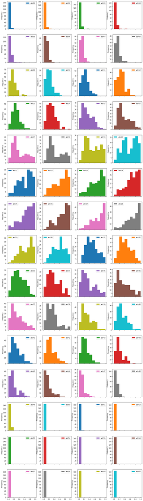

```python
# Histograms for each attribute
df_features_train.plot(kind='hist', subplots=True, layout=(display_rows, display_columns))
plt.show()
```

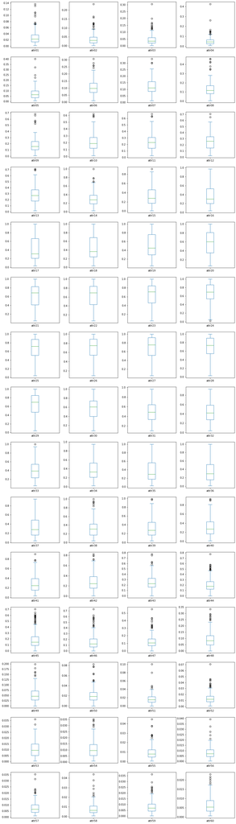

```python
# Box and Whisker plot for each attribute
df_features_train.plot(kind='box', subplots=True, layout=(display_rows, display_columns))
plt.show()
```

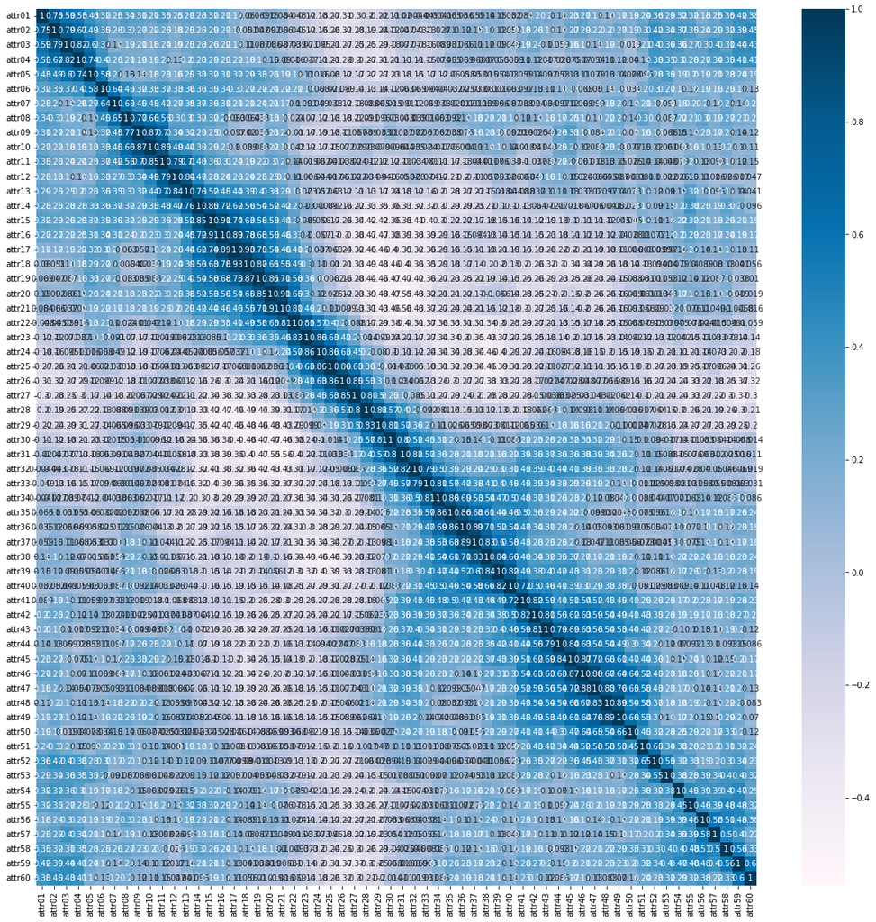

```python
# Correlation matrix
fig = plt.figure(figsize=(20, 20))
correlations = df_features_train.corr(method='pearson')
sns.heatmap(correlations, annot=True, cmap=plt.cm.PuBu)
plt.show()
```

```python
if NOTIFY_STATUS: status_notify("Task 2 - Summarize and Visualize Data completed! " + datetime.now().strftime('%a %B %d, %Y %I:%M:%S %p'))
```

## Task 3 - Pre-process Data

```python
if NOTIFY_STATUS: status_notify("Task 3 - Pre-process Data has begun! " + datetime.now().strftime('%a %B %d, %Y %I:%M:%S %p'))
```

### 3.a) Feature Scaling

```python
# Compose pipeline for the numerical and categorical features (Block #1 of 2)
numeric_columns = df_features_train.select_dtypes(include=['int64','float64']).columns
numeric_transformer = Pipeline(steps=[
    ('imputer', impute.SimpleImputer(strategy="constant", fill_value=0)),
    ('scaler', preprocessing.MinMaxScaler())
])
categorical_columns = df_features_train.select_dtypes(include=['object','bool','category']).columns
categorical_transformer = Pipeline(steps=[
    ('imputer', impute.SimpleImputer(strategy='constant', fill_value='UKNOWN')),
    ('onehot', preprocessing.OneHotEncoder(sparse=False, handle_unknown='ignore'))
])

print("Number of numerical columns:", len(numeric_columns))
print("Number of categorical columns:", len(categorical_columns))
print("Total number of columns in the feature dataframe:", df_features_train.shape[1])
```

```
Number of numerical columns: 60
Number of categorical columns: 0
Total number of columns in the feature dataframe: 60
```

```python
# Compose pipeline for the numerical and categorical features (Block #2 of 2)
preprocessor = compose.ColumnTransformer(transformers=[
    ('num', numeric_transformer, numeric_columns),
    ('cat', categorical_transformer, categorical_columns)
])

# Display the shapes of the training dataset for final inspection
array_features_train = preprocessor.fit_transform(df_features_train)
print("Transformed features from df_features_train.shape: {} to array_features_train.shape: {}".format(df_features_train.shape, array_features_train.shape))
```

```
Transformed features from df_features_train.shape: (166, 60) to array_features_train.shape: (166, 60)
```

### 3.b) Training Data Balancing

```python
# Not applicable for this iteration of the project
```

```python
# Examine the target classes for imbalanced distribution
# Xy_original.groupby('targetVar').size()
```

```python
# # Perform SMOTE transformation on the training data (Block #1 of 2)
# X_train_imbal = X_train_df.values
# y_train_imbal = y_train_df.values.ravel()
# print("X_train_imbal.shape: {} y_train_imbal.shape: {}".format(X_train_imbal.shape, y_train_imbal.shape))
```

```python
# # Perform SMOTE transformation on the training data (Block #2 of 2)
# print ('Original class distribution - 1: {} | 0: {}'.format((y_train_imbal==1).sum(), (y_train_imbal==0).sum()))
# over_sample = SMOTE(sampling_strategy=0.05, random_state=RNG_SEED)
# under_sample = RandomUnderSampler(sampling_strategy=1.0, random_state=RNG_SEED)
# steps = [('o', over_sample), ('u', under_sample)]
# sample_pipeline = Pipeline(steps=steps)
# X_train, y_train = sample_pipeline.fit_resample(X_train_imbal, y_train_imbal)
# print ('Resampled class distribution - 1: {} | 0: {}'.format((y_train==1).sum(), (y_train==0).sum()))
```

### 3.c) Display the Final Datasets for Model-Building

```python
# Finalize the training dataset for the modeling activities
# array_features_train = df_features_train.to_numpy()
array_target_train = df_target_train.ravel()
# label_encoder = preprocessing.LabelEncoder()
# array_target_train = label_encoder.fit_transform(df_target_train)
print("array_features_train.shape: {} array_target_train.shape: {}".format(array_features_train.shape, array_target_train.shape))
```

```
array_features_train.shape: (166, 60) array_target_train.shape: (166,)
```

```python
if NOTIFY_STATUS: status_notify("Task 3 - Pre-process Data completed! " + datetime.now().strftime('%a %B %d, %Y %I:%M:%S %p'))
```

## Task 4 - Train and Tune Models

```python
if NOTIFY_STATUS: status_notify("Task 4 - Train and Tune Models has begun! " + datetime.now().strftime('%a %B %d, %Y %I:%M:%S %p'))
```

```python
start_time_module = datetime.now()
reset_random()
auto_model = ak.StructuredDataClassifier(loss=DEFAULT_LOSS,
                                      metrics=DEFAULT_METRICS,
                                      max_trials=MAX_TRIALS,
                                      objective=keras_tuner.Objective("val_auc", direction="max"),
                                      seed=RNG_SEED)
auto_model.fit(x=array_features_train,
               y=array_target_train,
               epochs=MAX_EPOCHS,
               validation_split=VAL_SET_RATIO,
               batch_size=BATCH_SIZE,
               verbose=1)
print('Total time for model fitting:', (datetime.now() - start_time_module))
```

```
Trial 67 Complete [00h 00m 05s]
val_auc: 0.7343749403953552

Best val_auc So Far: 1.0
Total elapsed time: 00h 19m 19s
INFO:tensorflow:Oracle triggered exit
```

```
2022-01-05 18:32:16.335377: W tensorflow/python/util/util.cc:348] Sets are not currently considered sequences, but this may change in the future, so consider avoiding using them.
```

```
INFO:tensorflow:Assets written to: ./structured_data_classifier/best_model/assets
Total time for model fitting: 0:19:24.721749
```

```python
if NOTIFY_STATUS: status_notify("Task 4 - Train and Tune Models completed! " + datetime.now().strftime('%a %B %d, %Y %I:%M:%S %p'))
```

## Task 5 - Finalize Model and Make Predictions

```python
if NOTIFY_STATUS: status_notify("Task 5 - Finalize Model and Make Predictions has begun! " + datetime.now().strftime('%a %B %d, %Y %I:%M:%S %p'))
```

### 5.a) Train the Final Model

```python
final_model = auto_model.export_model()
final_model.summary()
```

```
Model: "model"
_________________________________________________________________
Layer (type)                 Output Shape              Param #
=================================================================
input_1 (InputLayer)         [(None, 60)]              0
_________________________________________________________________
multi_category_encoding (Mul (None, 60)                0
_________________________________________________________________
normalization (Normalization (None, 60)                121
_________________________________________________________________
dense (Dense)                (None, 128)               7808
_________________________________________________________________
re_lu (ReLU)                 (None, 128)               0
_________________________________________________________________
dense_1 (Dense)              (None, 16)                2064
_________________________________________________________________
re_lu_1 (ReLU)               (None, 16)                0
_________________________________________________________________
dense_2 (Dense)              (None, 1)                 17
_________________________________________________________________
classification_head_1 (Activ (None, 1)                 0
=================================================================
Total params: 10,010
Trainable params: 9,889
Non-trainable params: 121
_________________________________________________________________
```

### 5.b) Load Test Dataset and Make Predictions

```python
# Finalize the test dataset for the testing activities
array_features_test = preprocessor.transform(df_features_test)
array_target_test = df_target_test.ravel()
# array_target_test = label_encoder.transform(df_target_test)
print("array_features_test.shape: {} array_target_test.shape: {}".format(array_features_test.shape, array_target_test.shape))
```

```
array_features_test.shape: (42, 60) array_target_test.shape: (42,)
```

```python
# Make batched predictions
test_predictions = final_model.predict(array_features_test)
print(test_predictions)
```

```
[[1.83583245e-01]
 [2.56165204e-05]
 [8.10624260e-05]
 [9.63189602e-01]
 [3.50531004e-03]
 [1.97950620e-02]
 [4.72262129e-02]
 [9.98467147e-01]
 [2.22256601e-01]
 [9.32850176e-04]
 [3.13063003e-02]
 [1.26965766e-04]
 [5.40271163e-01]
 [9.99236345e-01]
 [6.09594223e-04]
 [7.18970954e-01]
 [1.19644925e-01]
 [8.01513996e-03]
 [1.02359794e-01]
 [4.86248322e-02]
 [3.15456279e-02]
 [1.69074629e-02]
 [9.87482905e-01]
 [1.64784273e-04]
 [4.53391141e-04]
 [7.55611658e-01]
 [1.24627575e-02]
 [1.43143337e-03]
 [7.71400109e-02]
 [1.07915796e-01]
 [9.58724380e-01]
 [1.44057523e-03]
 [5.51033719e-03]
 [9.88321245e-01]
 [9.15178955e-01]
 [6.75056577e-01]
 [2.21075211e-02]
 [8.10741067e-01]
 [9.91633892e-01]
 [4.10841815e-02]
 [6.38190269e-01]
 [9.99622822e-01]]
```

```python
# print('Accuracy Score:', accuracy_score(array_target_test, test_predictions))
print('ROC/AUC Score:', roc_auc_score(array_target_test, test_predictions), '\n')
# print(confusion_matrix(array_target_test, test_predictions), '\n')
# print(classification_report(array_target_test, test_predictions))
```

```
ROC/AUC Score: 0.9037037037037037
```

```python
if NOTIFY_STATUS: status_notify("Task 5 - Finalize Model and Make Predictions completed! " + datetime.now().strftime('%a %B %d, %Y %I:%M:%S %p'))
```

```python
print ('Total time for the script:',(datetime.now() - START_TIME_SCRIPT))
```

```
Total time for the script: 0:19:48.811182
```